# Neural Network Hyperparameter Tuning - Reweighing

Following the completion of the grid search, our primary aim is to identify the hyperparameter set exhibiting the highest accuracy and AUC on the validation sets within the k-fold cross-validation. This best-performing hyperparameter set will subsequently serve as the base for the final model configuration, embodying a compromise between computational efficiency and predictive accuracy.

[output not shown]

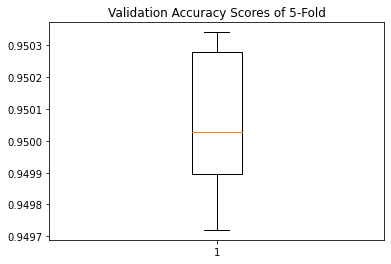

```
Running with hyperparameters: {'batch_size': 100000, 'epochs': 40, 'layers': 1, 'learning_rate': 0.01, 'neurons': 10}
> Accuracy: 94.990, AUC: 60.491
> Accuracy: 95.003, AUC: 49.998
> Accuracy: 95.030, AUC: 59.371
> Accuracy: 95.034, AUC: 59.321
> Accuracy: 94.971, AUC: 57.512
AUC: mean=57.339 std=3.792, n=5
Accuracy: mean=95.006 std=0.024, n=5
```

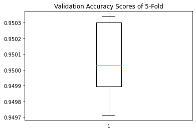

```
Running with hyperparameters: {'batch_size': 100000, 'epochs': 40, 'layers': 1, 'learning_rate': 0.01, 'neurons': 15}
> Accuracy: 94.989, AUC: 59.093
> Accuracy: 95.003, AUC: 60.410
> Accuracy: 95.030, AUC: 60.022
> Accuracy: 95.034, AUC: 58.630
> Accuracy: 94.972, AUC: 59.752
AUC: mean=59.581 std=0.641, n=5
Accuracy: mean=95.005 std=0.024, n=5
```

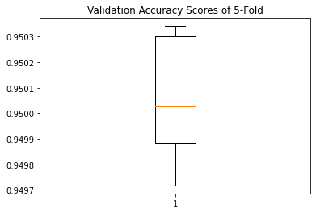

```
Running with hyperparameters: {'batch_size': 100000, 'epochs': 40, 'layers': 2, 'learning_rate': 0.01, 'neurons': 5}
> Accuracy: 94.989, AUC: 58.139
> Accuracy: 95.003, AUC: 59.940
> Accuracy: 95.025, AUC: 59.496
> Accuracy: 95.034, AUC: 49.976
> Accuracy: 94.971, AUC: 50.000
AUC: mean=55.510 std=4.548, n=5
Accuracy: mean=95.004 std=0.023, n=5
```

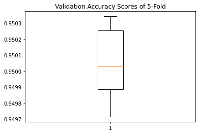

```
Running with hyperparameters: {'batch_size': 100000, 'epochs': 40, 'layers': 2, 'learning_rate': 0.01, 'neurons': 10}
> Accuracy: 94.990, AUC: 60.531
> Accuracy: 94.996, AUC: 60.141
> Accuracy: 95.030, AUC: 60.523
> Accuracy: 95.034, AUC: 60.045
> Accuracy: 94.972, AUC: 60.509
AUC: mean=60.350 std=0.212, n=5
Accuracy: mean=95.004 std=0.024, n=5
```

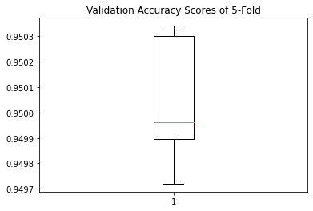

```
Running with hyperparameters: {'batch_size': 100000, 'epochs': 40, 'layers': 2, 'learning_rate': 0.01, 'neurons': 15}
> Accuracy: 94.989, AUC: 60.739
> Accuracy: 95.003, AUC: 59.702
> Accuracy: 95.030, AUC: 57.544
> Accuracy: 95.034, AUC: 49.993
> Accuracy: 94.971, AUC: 59.052
AUC: mean=57.406 std=3.849, n=5
Accuracy: mean=95.005 std=0.024, n=5
```

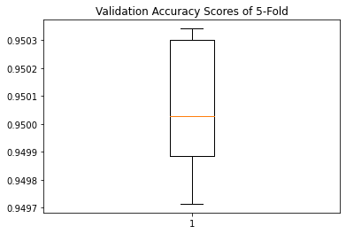

```
Running with hyperparameters: {'batch_size': 100000, 'epochs': 40, 'layers': 3, 'learning_rate': 0.01, 'neurons': 5}
> Accuracy: 94.990, AUC: 57.906
> Accuracy: 95.003, AUC: 59.969
> Accuracy: 95.030, AUC: 59.760
> Accuracy: 95.034, AUC: 50.000
> Accuracy: 94.971, AUC: 50.000
AUC: mean=55.527 std=4.570, n=5
Accuracy: mean=95.006 std=0.024, n=5
```

```
Running with hyperparameters: {'batch_size': 100000, 'epochs': 40, 'layers': 3, 'learning_rate': 0.01, 'neurons': 10}
> Accuracy: 94.987, AUC: 60.387
> Accuracy: 95.003, AUC: 60.331
> Accuracy: 95.030, AUC: 61.107
> Accuracy: 95.034, AUC: 47.006
> Accuracy: 94.971, AUC: 58.919
AUC: mean=57.550 std=5.319, n=5
Accuracy: mean=95.005 std=0.024, n=5
```

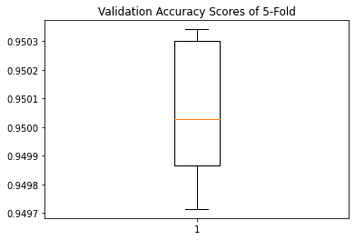

```
Running with hyperparameters: {'batch_size': 100000, 'epochs': 40, 'layers': 3, 'learning_rate': 0.01, 'neurons': 15}
> Accuracy: 94.990, AUC: 60.518
> Accuracy: 95.003, AUC: 59.619
> Accuracy: 95.030, AUC: 60.903
> Accuracy: 95.034, AUC: 60.494
> Accuracy: 94.971, AUC: 60.481
AUC: mean=60.403 std=0.422, n=5
Accuracy: mean=95.006 std=0.024, n=5
```

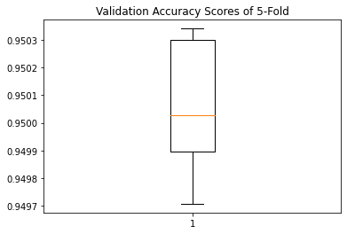

```
Running with hyperparameters: {'batch_size': 100000, 'epochs': 80, 'layers': 1, 'learning_rate': 0.01, 'neurons': 5}
> Accuracy: 94.990, AUC: 50.000
> Accuracy: 95.003, AUC: 59.690
> Accuracy: 95.030, AUC: 59.904
> Accuracy: 95.034, AUC: 61.034
> Accuracy: 94.971, AUC: 60.484
AUC: mean=58.222 std=4.138, n=5
Accuracy: mean=95.006 std=0.024, n=5
```

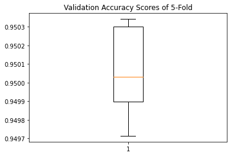

```
Running with hyperparameters: {'batch_size': 100000, 'epochs': 80, 'layers': 1, 'learning_rate': 0.01, 'neurons': 10}
> Accuracy: 94.990, AUC: 60.369
> Accuracy: 95.003, AUC: 61.107
> Accuracy: 95.030, AUC: 60.853
> Accuracy: 95.034, AUC: 60.100
> Accuracy: 94.972, AUC: 60.135
AUC: mean=60.513 std=0.401, n=5
Accuracy: mean=95.006 std=0.024, n=5
```

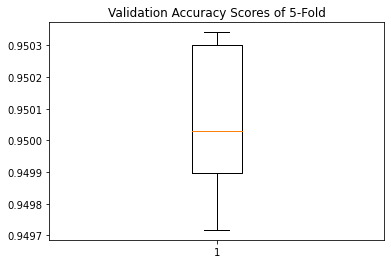

```
Running with hyperparameters: {'batch_size': 100000, 'epochs': 80, 'layers': 1, 'learning_rate': 0.01, 'neurons': 15}
> Accuracy: 94.989, AUC: 60.683
> Accuracy: 95.002, AUC: 60.859
> Accuracy: 95.030, AUC: 61.248
> Accuracy: 95.034, AUC: 61.137
> Accuracy: 94.971, AUC: 61.053
AUC: mean=60.996 std=0.202, n=5
Accuracy: mean=95.005 std=0.024, n=5
```

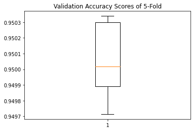

```
Running with hyperparameters: {'batch_size': 100000, 'epochs': 80, 'layers': 2, 'learning_rate': 0.01, 'neurons': 5}
> Accuracy: 94.990, AUC: 50.000
> Accuracy: 95.003, AUC: 60.817
> Accuracy: 95.030, AUC: 50.000
> Accuracy: 95.034, AUC: 61.415
> Accuracy: 94.972, AUC: 59.761
AUC: mean=56.398 std=5.251, n=5
Accuracy: mean=95.006 std=0.024, n=5
```

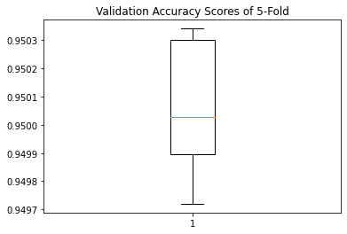

```
Running with hyperparameters: {'batch_size': 100000, 'epochs': 80, 'layers': 2, 'learning_rate': 0.01, 'neurons': 10}
> Accuracy: 94.987, AUC: 61.139
> Accuracy: 95.003, AUC: 61.218
> Accuracy: 95.030, AUC: 49.994
> Accuracy: 95.034, AUC: 60.492
> Accuracy: 94.971, AUC: 59.652
AUC: mean=58.499 std=4.289, n=5
Accuracy: mean=95.005 std=0.024, n=5
```

[13 more figures not shown]

```
Running with hyperparameters: {'batch_size': 250000, 'epochs': 80, 'layers': 3, 'learning_rate': 0.01, 'neurons': 15}
> Accuracy: 94.990, AUC: 57.803
> Accuracy: 95.003, AUC: 55.869
> Accuracy: 95.030, AUC: 58.049
> Accuracy: 95.034, AUC: 50.010
> Accuracy: 94.971, AUC: 57.693
AUC: mean=55.885 std=3.038, n=5
Accuracy: mean=95.006 std=0.024, n=5
```

```python
# Function to define the nn model
def define_model(input_dim, layers, neurons, loss_f, metric, learning_rate):
    model = Sequential()
    model.add(Dense(neurons, input_shape=(input_dim,), activation='relu', kernel_initializer='he_uniform'))

    for _ in range(layers - 1):
        model.add(Dense(neurons, activation='relu', kernel_initializer='he_uniform'))

    model.add(Dense(1, activation='sigmoid'))  # Output - binary
    opt = SGD(learning_rate=learning_rate, momentum=0.9)
    model.compile(optimizer=opt, loss=loss_f, weighted_metrics=metric)
    return model


####_______________________________________________________________________________________________________________________


# Function to evaluate the model using k-fold cross-validation
def evaluate_model(X_train, y_train, n_folds, loss_f, metric, epochs, batch_size, layers, neurons, learning_rate):
    scores, histories, aucs = list(), list(), list()
    kfold = KFold(n_folds, shuffle=True, random_state=1)

    for train_ix, test_ix in kfold.split(X_train):
        trainX, trainY, testX, testY = X_train.iloc[train_ix, :], y_train.iloc[train_ix], X_train.iloc[test_ix, :], y_train.iloc[test_ix]

        # Add Early stop
        early_stop = EarlyStopping(monitor='val_loss', patience=5, restore_best_weights=True)

        model = define_model(X_train.shape[1], layers, neurons, loss_f, metric, learning_rate)

        # Fit model
        history = model.fit(trainX, trainY, epochs=epochs, batch_size=batch_size,
                            validation_data=(testX, testY), verbose=0, callbacks=[early_stop])

        # Evaluate model
        loss, acc, auc = model.evaluate(testX, testY, verbose=0)

        # Compute AUC
        y_pred_proba = model.predict(testX, verbose=0)
        auc = roc_auc_score(testY, y_pred_proba)

        print('> Accuracy: %.3f, AUC: %.3f' % (acc * 100.0, auc * 100.0))


        # Append scores
        scores.append(acc)
        aucs.append(auc)
        histories.append(history)

    return scores, aucs, histories, model


####_______________________________________________________________________________________________________________________


# Function to plot diagnostic learning curves
def summarize_diagnostics(histories): #Not used here
    plt.figure(figsize=(15, 5))
    for i in range(len(histories)):
        plt.subplot(311)
        plt.title('Cross Entropy Loss')
        plt.plot(histories[i].history['loss'], color='blue', label='train')
        plt.plot(histories[i].history['val_loss'], color='orange', label='test')
        plt.subplot(312)
        plt.title('Classification Accuracy')
        plt.plot(histories[i].history['accuracy'], color='blue', label='train')
        plt.plot(histories[i].history['val_accuracy'], color='orange', label='test')
    plt.show()


####_______________________________________________________________________________________________________________________


# Function to summarize model performance
def summarize_performance(scores, aucs):
    print('AUC: mean=%.3f std=%.3f, n=%d' % (np.mean(aucs)*100, np.std(aucs)*100, len(aucs)))

    print('Accuracy: mean=%.3f std=%.3f, n=%d' % (np.mean(scores)*100, np.std(scores)*100, len(scores)))

    plt.boxplot(scores)
    plt.title('Validation Accuracy Scores of 5-Fold')
    plt.show()


####_______________________________________________________________________________________________________________________


# Function to run the test harness for evaluating a model
def run_test_harness(X_train, y_train, n_folds, loss_f, metric, epochs, batch_size, layers, neurons, learning_rate):
    scores, aucs, histories, model = evaluate_model(X_train, y_train, n_folds, loss_f, metric,
                                                    epochs, batch_size, layers, neurons, learning_rate)
#     summarize_diagnostics(histories)
    summarize_performance(scores, aucs)
    return scores, aucs


####_______________________________________________________________________________________________________________________


# Example hyperparameter grid for grid search
param_grid = {
    'epochs': [40, 80],
    'batch_size': [100000, 250000],
    'layers': [1, 2, 3],
    'neurons': [5, 10, 15],
    'learning_rate': [0.01]
}


####_______________________________________________________________________________________________________________________


# Perform grid search
best_score = 0.0
best_auc = 0.0

best_params_acc = None
best_params_auc = None

grid = ParameterGrid(param_grid)
for params in grid:
    print("Running with hyperparameters:", params)
    current_scores, current_aucs = run_test_harness(X_train, y_train,
                                                    n_folds=5, loss_f='binary_crossentropy',
                                                    metric=['accuracy', 'AUC'], **params)

    if np.mean(current_scores) > best_score:
        best_score = np.mean(current_scores)
        best_params_acc = params

    if np.mean(current_aucs) > best_auc:
        best_auc = np.mean(current_aucs)
        best_params_auc = params
```

```python
print("Best Hyperparameters based on accuracy:", best_params_acc)

print('\nAUC: mean=57.852 std=1.150, n=5\nAccuracy: mean=95.006 std=0.024, n=5\n\n')
```

```
Best Hyperparameters based on accuracy: {'batch_size': 250000, 'epochs': 40, 'layers': 1, 'learning_rate': 0.01, 'neurons': 15}

AUC: mean=57.852 std=1.150, n=5
Accuracy: mean=95.006 std=0.024, n=5
```

```python
print("Best Hyperparameters based on AUC:", best_params_auc)

print('\nAUC: mean=60.996 std=0.202, n=5\nAccuracy: mean=95.005 std=0.024, n=5')
```

```
Best Hyperparameters based on AUC: {'batch_size': 100000, 'epochs': 80, 'layers': 1, 'learning_rate': 0.01, 'neurons': 15}

AUC: mean=60.996 std=0.202, n=5
Accuracy: mean=95.005 std=0.024, n=5
```

**Conclusion**: When we compare the top two sets of hyperparameters—one optimized for accuracy and the other for AUC—we observe a minimal difference in accuracy, just 0.001%. However, the distinction becomes more apparent when we examine AUC. There is a more significant gap in both the average AUC and the consistency across the 5 validation folds, as indicated by the higher standard deviation of 1.15 in the best-Accuracy model compared to 0.202 in the best-AUC model. This leads us to favor the model with the highest AUC. Opting for this model provides a substantial improvement in AUC, ensuring more robust performance across various validations. The slight compromise in overall accuracy is overshadowed by the considerable gains in AUC and the heightened confidence in the model's performance.

This is similar to what we've seen in the Neural Network parameter tuning using the oversampling technique for balancing the data.

**Save the best-performance parameters**

```python
import pickle

# Save the dictionary to a file
with open('best_params_NN_reweighing.pkl', 'wb') as file:
    pickle.dump(best_params_auc, file)
```